# IS 4487 Assignment 5: Exploratory Data Analysis (EDA) with Stakeholder Framing

In this assignment, you will:

- Load and explore a hotel bookings dataset
- Identify stakeholder needs and frame your analysis around business goals
- Practice data summarization and visualization
- Draw insights that could lead to actionable business recommendations

## Why This Matters

These skills are essential for business majors and minors working in areas like marketing, operations, finance, or consulting. Understanding how to explore and communicate data-driven insights helps you make better decisions and contribute to real-world business outcomes.

## Dataset Description: Hotel Bookings

This dataset contains booking information for two types of hotels: a **city hotel** and a **resort hotel**. Each record corresponds to a single booking and includes various details about the reservation, customer demographics, booking source, and whether the booking was canceled.

**Source**: [GitHub - TidyTuesday: Hotel Bookings](https://github.com/rfordatascience/tidytuesday/blob/master/data/2020/2020-02-11/readme.md)

### Key Use Cases

- Understand customer booking behavior
- Explore factors related to cancellations
- Segment guests based on booking characteristics
- Compare city vs. resort hotel performance

### Data Dictionary

| Variable | Type | Description |
| --- | --- | --- |
| `hotel` | character | Hotel type: City or Resort |
| `is_canceled` | integer | 1 = Canceled, 0 = Not Canceled |
| `lead_time` | integer | Days between booking and arrival |
| `arrival_date_year` | integer | Year of arrival |
| `arrival_date_month` | character | Month of arrival |
| `stays_in_weekend_nights` | integer | Nights stayed on weekends |
| `stays_in_week_nights` | integer | Nights stayed on weekdays |
| `adults` | integer | Number of adults |
| `children` | integer | Number of children |
| `babies` | integer | Number of babies |
| `meal` | character | Type of meal booked |
| `country` | character | Country code of origin |
| `market_segment` | character | Booking source (e.g., Direct, Online TA) |
| `distribution_channel` | character | Booking channel used |
| `is_repeated_guest` | integer | 1 = Repeated guest, 0 = New guest |
| `previous_cancellations` | integer | Past booking cancellations |
| `previous_bookings_not_canceled` | integer | Past bookings not canceled |
| `reserved_room_type` | character | Initially reserved room type |
| `assigned_room_type` | character | Room type assigned at check-in |
| `booking_changes` | integer | Number of booking modifications |
| `deposit_type` | character | Deposit type (No Deposit, Non-Refund, etc.) |
| `agent` | character | Agent ID who made the booking |
| `company` | character | Company ID (if booking through company) |
| `days_in_waiting_list` | integer | Days on the waiting list |
| `customer_type` | character | Booking type: Contract, Transient, etc. |
| `adr` | float | Average Daily Rate (price per night) |
| `required_car_parking_spaces` | integer | Requested parking spots |
| `total_of_special_requests` | integer | Number of special requests made |
| `reservation_status` | character | Final status (Canceled, No-Show, Check-Out) |
| `reservation_status_date` | date | Date of the last status update |

This dataset is ideal for classification, segmentation, and trend analysis exercises.

## 1. Setup and Data Loading

Instructions:

- Import `pandas`, `seaborn`, and `matplotlib.pyplot`.
- Import data from the hotels dataset into a dataframe (in GitHub go to the DataSets folder and look for `hotels.csv`)
- Display the first few rows to confirm it loaded correctly.

```python
# Your code to import libraries and load data goes here
import pandas as pd
import seaborn as sns
import matplotlib.pyplot as plt

url = 'https://raw.githubusercontent.com/Stan-Pugsley/is_4487_base/refs/heads/main/DataSets/hotels.csv'
df = pd.read_csv(url)
df.head()
```

|  | hotel | is_canceled | lead_time | arrival_date_year | arrival_date_month | arrival_date_week_number | arrival_date_day_of_month | stays_in_weekend_nights | stays_in_week_nights | adults | ... | deposit_type | agent | company | days_in_waiting_list | customer_type | adr | required_car_parking_spaces | total_of_special_requests | reservation_status | reservation_status_date |
| --- | --- | --- | --- | --- | --- | --- | --- | --- | --- | --- | --- | --- | --- | --- | --- | --- | --- | --- | --- | --- | --- |
| 0 | Resort Hotel | 0 | 342 | 2015 | July | 27 | 1 | 0 | 0 | 2 | ... | No Deposit | NaN | NaN | 0 | Transient | 0.0 | 0 | 0 | Check-Out | 2015-07-01 |
| 1 | Resort Hotel | 0 | 737 | 2015 | July | 27 | 1 | 0 | 0 | 2 | ... | No Deposit | NaN | NaN | 0 | Transient | 0.0 | 0 | 0 | Check-Out | 2015-07-01 |
| 2 | Resort Hotel | 0 | 7 | 2015 | July | 27 | 1 | 0 | 1 | 1 | ... | No Deposit | NaN | NaN | 0 | Transient | 75.0 | 0 | 0 | Check-Out | 2015-07-02 |
| 3 | Resort Hotel | 0 | 13 | 2015 | July | 27 | 1 | 0 | 1 | 1 | ... | No Deposit | 304.0 | NaN | 0 | Transient | 75.0 | 0 | 0 | Check-Out | 2015-07-02 |
| 4 | Resort Hotel | 0 | 14 | 2015 | July | 27 | 1 | 0 | 2 | 2 | ... | No Deposit | 240.0 | NaN | 0 | Transient | 98.0 | 0 | 1 | Check-Out | 2015-07-03 |

5 rows × 32 columns

## 2. Stakeholder and Business Context

### Business framing:

Every analysis should serve a decision-maker. Before you explore the data, identify who cares about hotel booking behavior and what they might want to know. Your analysis should be framed around those needs.

### Reflection:

1. Who are the key stakeholders for this dataset?
2. What goals might each stakeholder have?
3. What is a clear, specific business problem statement that this data can help answer?

### ✍️ Your Response: 🔧

1. I think the key stakeholders for this dataset are hotel owners and managers as they are liable for optimizing bookings, lowering cancellations, and building guest loyalty.
2. I think that the goals of hotel owners and managers consist of identifying characteristics associated with cancellations and behaviors of returning guests, reducing cancellations to save a sale from being lost, and increasing guest retention rates.
3. Hotel owners and managers need to identify and understand which booking traits are connected with cancellations and repeat guests, so they can reduce cancellations and enhance customer retention.

## 3. Explore Data Structure and Quality

### Business framing:

Before diving into analysis, analysts need to understand the shape and health of the data. Bad data leads to bad decisions.

### Do the following:

- Perform the following 3 checks to see the data quality:
  - Summary the data (e.g., `.info()`, `.describe()`)
  - Find the number of Null values
  - Find the number of duplicate row checks

```python
# Summary of Data
df.info()
df.describe()
```

```
<class 'pandas.core.frame.DataFrame'>
RangeIndex: 9404 entries, 0 to 9403
Data columns (total 32 columns):
 #   Column                          Non-Null Count  Dtype
---  ------                          --------------  -----
 0   hotel                           9404 non-null   object
 1   is_canceled                     9404 non-null   int64
 2   lead_time                       9404 non-null   int64
 3   arrival_date_year               9404 non-null   int64
 4   arrival_date_month              9404 non-null   object
 5   arrival_date_week_number        9404 non-null   int64
 6   arrival_date_day_of_month       9404 non-null   int64
 7   stays_in_weekend_nights         9404 non-null   int64
 8   stays_in_week_nights            9404 non-null   int64
 9   adults                          9404 non-null   int64
```

[output cut: 24 more lines]

|  | is_canceled | lead_time | arrival_date_year | arrival_date_week_number | arrival_date_day_of_month | stays_in_weekend_nights | stays_in_week_nights | adults | children | babies | is_repeated_guest | previous_cancellations | previous_bookings_not_canceled | booking_changes | agent | company | days_in_waiting_list | adr | required_car_parking_spaces | total_of_special_requests |
| --- | --- | --- | --- | --- | --- | --- | --- | --- | --- | --- | --- | --- | --- | --- | --- | --- | --- | --- | --- | --- |
| count | 9404.000000 | 9404.000000 | 9404.000000 | 9404.000000 | 9404.000000 | 9404.000000 | 9404.000000 | 9404.000000 | 9404.000000 | 9404.000000 | 9404.000000 | 9404.000000 | 9404.000000 | 9404.000000 | 7069.000000 | 1011.000000 | 9404.000000 | 9404.000000 | 9404.000000 | 9404.000000 |
| mean | 0.248299 | 79.326244 | 2015.156104 | 37.026584 | 15.515313 | 1.155040 | 3.078690 | 1.864738 | 0.095279 | 0.015419 | 0.077839 | 0.419715 | 0.290196 | 0.238622 | 200.990946 | 219.550940 | 1.019034 | 86.843614 | 0.144938 | 0.613143 |
| std | 0.432049 | 87.584146 | 0.443661 | 11.083421 | 9.025545 | 1.124304 | 2.379227 | 1.198565 | 0.393858 | 0.125781 | 0.267933 | 2.726546 | 1.352679 | 0.630041 | 80.330753 | 104.296474 | 10.137928 | 53.759940 | 0.353264 | 0.835930 |
| min | 0.000000 | 0.000000 | 2015.000000 | 1.000000 | 1.000000 | 0.000000 | 0.000000 | 0.000000 | 0.000000 | 0.000000 | 0.000000 | 0.000000 | 0.000000 | 0.000000 | 1.000000 | 9.000000 | 0.000000 | -6.380000 | 0.000000 | 0.000000 |
| 25% | 0.000000 | 8.000000 | 2015.000000 | 31.000000 | 7.000000 | 0.000000 | 1.000000 | 2.000000 | 0.000000 | 0.000000 | 0.000000 | 0.000000 | 0.000000 | 0.000000 | 156.000000 | 135.000000 | 0.000000 | 45.000000 | 0.000000 | 0.000000 |
| 50% | 0.000000 | 48.000000 | 2015.000000 | 38.000000 | 16.000000 | 1.000000 | 3.000000 | 2.000000 | 0.000000 | 0.000000 | 0.000000 | 0.000000 | 0.000000 | 0.000000 | 240.000000 | 223.000000 | 0.000000 | 71.550000 | 0.000000 | 0.000000 |
| 75% | 0.000000 | 118.000000 | 2015.000000 | 45.000000 | 23.000000 | 2.000000 | 5.000000 | 2.000000 | 0.000000 | 0.000000 | 0.000000 | 0.000000 | 0.000000 | 0.000000 | 241.000000 | 286.000000 | 0.000000 | 120.600000 | 0.000000 | 1.000000 |
| max | 1.000000 | 737.000000 | 2017.000000 | 53.000000 | 31.000000 | 13.000000 | 33.000000 | 55.000000 | 10.000000 | 2.000000 | 1.000000 | 26.000000 | 26.000000 | 17.000000 | 468.000000 | 511.000000 | 122.000000 | 508.000000 | 2.000000 | 5.000000 |

```python
# Number of Null Values
df.isnull().sum()
```

|  | 0 |
| --- | --- |
| hotel | 0 |
| is_canceled | 0 |
| lead_time | 0 |
| arrival_date_year | 0 |
| arrival_date_month | 0 |
| arrival_date_week_number | 0 |
| arrival_date_day_of_month | 0 |
| stays_in_weekend_nights | 0 |
| stays_in_week_nights | 0 |
| adults | 0 |
| children | 0 |
| babies | 0 |
| meal | 0 |
| country | 266 |
| market_segment | 0 |
| distribution_channel | 0 |
| is_repeated_guest | 0 |
| previous_cancellations | 0 |
| previous_bookings_not_canceled | 0 |
| reserved_room_type | 0 |
| assigned_room_type | 0 |
| booking_changes | 0 |
| deposit_type | 0 |
| agent | 2335 |
| company | 8393 |
| days_in_waiting_list | 0 |
| customer_type | 0 |
| adr | 0 |
| required_car_parking_spaces | 0 |
| total_of_special_requests | 0 |
| reservation_status | 0 |
| reservation_status_date | 0 |

**dtype:** int64

```python
# Number of Duplicate Rows
df.duplicated().sum()
```

```
np.int64(1674)
```

### Reflection:

1. Name at least one structure issue you’ve found (e.g., missing values, formatting problems).
2. How can you fix this structural issue?

### ✍️ Your Response: 🔧

1. One structure issue is that there are 1,674 repeated rows.
2. I would fix this structural issue by rechecking and ensuring that the rows are actually duplicated then removing the repeated rows to save space and storage.

## 4. Univariate Analysis

### Business framing:

Hotels care about trends like average stay length, customer mix, and pricing. A good EDA starts with understanding single variables and their distribution.

### Do the following:

- Select at least 3 individual variables to explore
- Use plots and summary methods (e.g. info(), describe(), etc) to describe the distribution (hint: we are only looking at the values of one variable, so think of plots you've used in the past that DON'T compare 2 variables.)
- Focus on what matters from a business standpoint (e.g., pricing, cancellations, guest types)

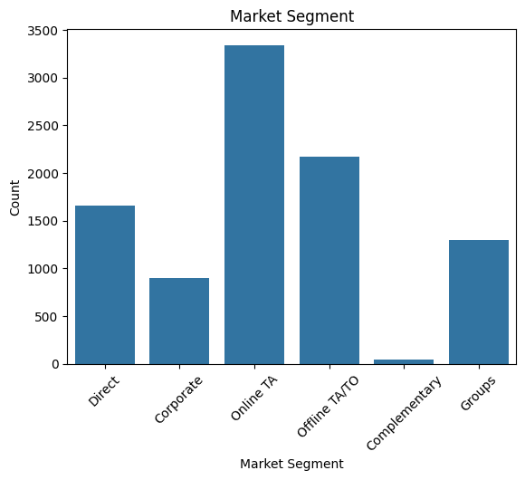

```python
# Variable 1: Market Segment
sns.countplot(data=df, x="market_segment")
plt.title("Market Segment")
plt.xlabel("Market Segment")
plt.ylabel("Count")
plt.xticks(rotation=45)
plt.show()
```

[figure not shown]

```python
# Variable 2: Month of Arrival

sns.countplot(data=df, x="arrival_date_month", order=months)
plt.title("Month of Arrival")
plt.xlabel("Month of Arrival")
plt.ylabel("Number of Bookings")
months = ["January", "February", "March", "April", "May", "June",
    "July", "August", "September", "October", "November", "December"]
plt.xticks(rotation=45)
plt.show()
```

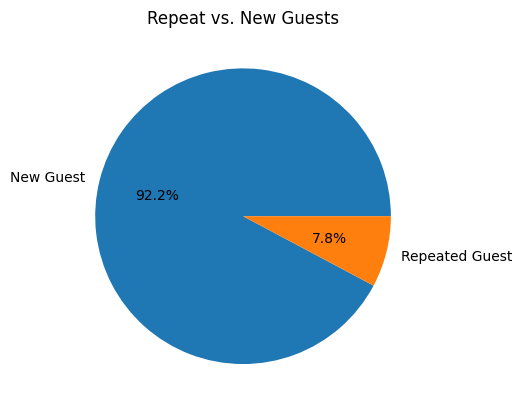

```python
# Variable 3: Repeat Guests vs. New Guests
plt.pie(df['is_repeated_guest'].value_counts(), labels=['New Guest', 'Repeated Guest'], autopct='%1.1f%%')
plt.title('Repeat vs. New Guests')
plt.show()
```

### Reflection:

1. Variable 1 – What did you explore and what did you find?
2. Variable 2 – What did you explore and what did you find?
3. Variable 3 – What did you explore and what did you find?

### ✍️ Your Response: 🔧

- **Variable 1 – Summary and insights:** I explored the market segment for hotel booking sources via bar chart. I see that online booking is the most popular while complementary is the least.
- **Variable 2 – Summary and insights:** I explored the number of bookings per calendar month using a bar chart. I notice that bookings are exceptionally high the second half of the year compared to the first half.
- **Variable 3 – Summary and insights:** Using a pie chart, I explored the percentages of returning and new guests. A majority of guests at 92.2% are new guests while 7.8% are repeat guests.

## 5. Bivariate Analysis

### Business framing:

Stakeholders often ask: “What drives cancellations?” or “Do longer stays mean higher revenue?” Bivariate analysis helps you uncover those kinds of relationships.

### Do the following:

- Choose 2 relevant variable pairs (e.g., `lead_time` vs. `is_canceled`, or `adr` vs. `customer_type`)
- Use scatterplots, grouped bar plots, or boxplots to explore the relationships
- Interpret what these relationships could mean for the hotel business

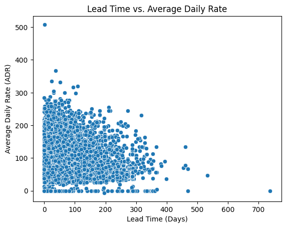

```python
# Relationship 1: Lead Time vs. Average Daily Rate

sns.scatterplot(data=df, x='lead_time', y='adr')

plt.xlabel('Lead Time (Days)')
plt.ylabel('Average Daily Rate (ADR)')
plt.title('Lead Time vs. Average Daily Rate')
plt.show()
```

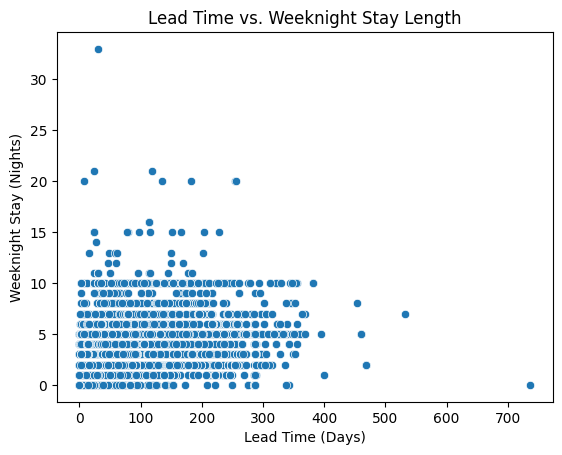

```python
# Relationship 2: Lead Time vs. Weeknight Stay Length
sns.scatterplot(data=df, x='lead_time', y='stays_in_week_nights')

plt.xlabel('Lead Time (Days)')
plt.ylabel('Weeknight Stay (Nights)')
plt.title('Lead Time vs. Weeknight Stay Length')
plt.show()
```

1. Relationship 1 – What did you analyze and what insights did you find?
2. Relationship 2 – What did you analyze and what insights did you find?

## 6. Problem Complexity and Analytics Framing

### Business framing:

Let’s say you found a strong trend — maybe high lead times predict cancellations, or certain channels bring repeat guests. What kind of problem is this?

- Choose one insight from your earlier analysis
- Reflect on:
  - What type of complexity this problem represents (e.g., variety, volume, variability)
  - What kind of analytics would help solve or explain it (descriptive, diagnostic, predictive, prescriptive)

### Reflection:

1. What was your selected insight?
2. What kind of complexity does it involve?
3. What type of analytics would help, and why?

### ✍️ Your Response: 🔧

1. I chose my insight from my univariate pie chart showcasing the percentage of new guests versus repeat guests.
2. This problem represents variety because there's only two types of guests: new and returning. I also think it represents variability because there must be variability in guest experience if only 7.8% of guests are choosing to return.
3. I think the best analytics to solve or explain this is diagnostic analytics because hotel managers want to know why over 90% of guests are new and only 7.8% are coming back, so that they can improve their guest retention and gain profit.

## 7. Final Takeaways and Recommendations

### Business framing:

Imagine you’re preparing for a stakeholder meeting. What would you highlight from your findings?

### Reflection:

- 1. What patterns or trends stood out?
- 2. How do they connect to stakeholder goals?
- 3. What recommendation would you make based on this analysis?
- 4. How does this relate to your customized learning outcome you created in canvas?

### ✍️ Your Response: 🔧

1. I found that my univariate trends stood out the most including the bookings per month bar chart and the pie chart of new and repeat guests.
2. I think the booking per month bar chart connect to stakeholder goals because it helps identify the dry months when guests don't stay at hotels. This can help stakeholders such as managers and owners to create strategies to increase bookings during those first 6 months of the year like offering promotions or discounts. I think the pie chart aligns with stakeholder goals because hotel managers can investigate why guests aren't returning and find solutions to maintain guest loyalty and retention.
3. I would suggest that stakeholders experiment with promotions and deals during the first half of the year to fill hotel rooms and increase revenue. I'd also suggest sending a survey to guests after their stay to know what guests enjoyed and didn't, so they can continue improving to retain returning guests.
4. This touches my customized learning outcome because I'm evaluating data and thinking critically to propose ideas like surveys and seasonal promotions to decisonmakers.

## Submission Instructions

✅ **Before submitting:**

- Make sure all code cells are run and outputs are visible
- All markdown questions are answered thoughtfully
- Submit the assignment as an **HTML file** on Canvas

```python
!jupyter nbconvert --to html "assignment_05_eda.ipynb"
```